# Descriptive Statistics

##### Libraries

```r
# ============================
# Data Manipulation / Databases
# ============================
library(tidyverse)   # Collection of packages for data manipulation (dplyr, tidyr) and visualization (ggplot2)
library(dplyr)       # Data manipulation: filtering, summarizing, joining
library(plyr)        # Older data manipulation package (mostly superseded by dplyr)
library(dbplyr)      # Interface to translate dplyr syntax to SQL for databases

# ============================
# Descriptive Statistics & Visualization
# ============================
library(ggplot2)     # Flexible and powerful plotting system
library(ggpubr)      # Easy-to-use publication-ready plots with ggplot2 enhancements
library(lattice)     # Alternative plotting system for multi-panel plots
library(descr)       # Descriptive statistics: frequency tables, crosstabs
library(Rmisc)       # Utility functions for summaries: mean, SE, CI
library(knitr)       # Dynamic report generation, integration with R Markdown
library(kableExtra)  # Enhanced tables for knitr and R Markdown
```

##### Import Data

```r
dataseniors<-read.csv2("seniors2.csv", sep=";", dec=",")#read data
data.df<-data.frame(dataseniors[1:310,1:31])#data frame(rectangular data structures)
```

# Types of Variables

## Scale of Measurement

There are four scales of measurement. They can be categorized by their properties:

- **Order:** Can I say one variable is bigger or less than another? (2 is greater than 1)
- **Difference:** Can I calculate one variable minus the other? (men minus female, doesn’t work)
- **Ratio:** Can I double the variable to get a second variable? (i.e. 200 is the double of 100)

### 1. Nominal Variables

**Nominal variables** have classes or categories which do not have an order, a difference, or a ratio.

- ex. male vs female, seasons of the year, body type

#### Pie Chart

```r
p <- ggplot(mpg) + # data
  aes("cars", fill=class) + # variable, fill to class of data
  geom_bar() + # chart type
  coord_polar(theta="y") + # make the bars a pie
  theme_void() + # remove theme
  coord_polar(theta="y", start = 45, direction = -1) # change start angle and direction
```

```
ℹ Adding new coordinate system, which will replace the existing one.
```

```r
p
```

[figure not shown]

#### Frequency Bar Chart

```r
bxp <- ggplot(data.df, aes(x = gender)) + # x = gender -> Variable to plot
  geom_bar(aes(y = after_stat(count) / sum(after_stat(count))), # after_stat(count) = absolute freq
           fill = "orange") + # after_stat(count) / sum(after_stat(count)) = relative freq
  labs(y = "f_i")
bxp
```

[figure not shown]

#### Bar Chart

```r
bxp <- ggplot(data.df, aes(x = gender)) +
  geom_bar(fill = "orange")
bxp
```

[figure not shown]

### 2. Ordinal Variables

**Ordinal variables** have classes or categories which have an order, but do not have a difference or ratio.

- ex. ranking of favorite foods

```r
dp2 <- ggplot(data.df, aes(x = numfamily)) +
  geom_bar(aes(y = after_stat(count) / sum(after_stat(count))),
           fill = "green") +
  labs(y = "f_i")
dp2
```

[figure not shown]

### 3. Interval Variables

**Interval variables** are related to lecker scales (related to levels of satisfaction). It is different from ordinal because it is related specifically to numbers. They have an order and a difference, but do not have a ratio.

- ex. ratings of satisfaction, temperature

#### Bar Chart

```r
dp1 <- ggplot(data.df, aes(x = education)) +
  geom_bar(aes(y = after_stat(count) / sum(after_stat(count))),
           fill = "red") +
  labs(y = "f_i")
dp1
```

[figure not shown]

### 4. Ratio Variables

- ex. weight, score on an exam

```r
dp <- ggplot(data.df, aes(x = price)) +
  geom_bar(aes(y = after_stat(count) / sum(after_stat(count))),
           fill = "lightblue") +
  labs(y = "f_i")
dp
```

[figure not shown]

#### Histogram (Absolute Frequency)

```r
data.fr<-data.frame(data.df[1:310,2:13])
ggplot(data.fr, aes(x = price)) +
  geom_histogram(bins=10, fill="lightblue",
                 color="black")
```

[figure not shown]

#### Histogram (Relative Frequency)

```r
ggplot(data.fr, aes(x = value)) +
  geom_histogram(aes(y = after_stat(count) / sum(after_stat(count))),
                 bins=15, fill="steelblue", color="white") +
  labs(y = "relative freq")
```

[figure not shown]

## Continuous Variables

A **continuous variable** can take on an unlimited number of values within a given range, meaning it can be a decimal, fraction, or whole number.

- ex. height of a person, temperature, etc.

#### Bar Chart

```r
price_bar <- ggplot(data.df, aes(x = price)) +
  geom_bar(aes(y = after_stat(count) / sum(after_stat(count))),
           fill = "brown") +
  labs(y = "f_i")
price_bar
```

[figure not shown]

#### Density Plot

```r
ggplot(data.fr, aes(x = value)) +
  geom_density(fill="skyblue", alpha=0.5)
```

[figure not shown]

## Discrete Variables

A **discrete variable** can only take on a specific, countable number of distinct values, often whole numbers, and cannot have fractional or decimal values between them.

- ex. number of siblings, number of jobs before starting a masters, level of happiness, etc

```r
walking_bar <- ggplot(data.df, aes(x = walking)) +
  geom_bar(aes(y = after_stat(count) / sum(after_stat(count))),
           fill = "pink") +
  labs(y = "f_i")
walking_bar
```

[figure not shown]

## Quantitative Variables

A **quantitative variable** varies by amount. This variable is measured numerically and is often collected by measuring or counting.

- ex. height, number of siblings

```r
#
```

## Qualitative Variables

A **qualitative variable** varies by class or category. This variable is often represented as a label and describes non-numeric aspects of phenomena. These will always be discrete variables.

- ex. zip code, level of happiness

#### Box Plot

```r
dp<-ggplot(data.df,mapping=aes(y=price))+geom_boxplot(fill="lightblue")
dp
```

[figure not shown]

## Common Variables and their Classification

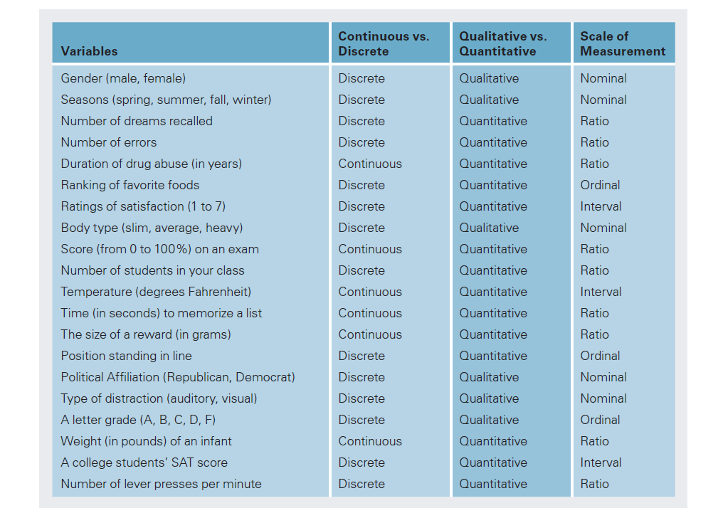

# Univariate Descriptive Analysis

## Measures of Central Tendency

**Measures of central tendency** describe the typical respondent or response

### Mode

**Mode** = category with the highest frequency

- Can be used with nominal, ordinal, interval or ratio variables
- It is possible to have more than one mode
- Should not be confused with majority (majority means more than 50% belongs in one category)
- Not very informative since it only uses data from one category
- Robust (not sensible to extreme values in data)

### Median

**Median** = physical center of the ordered data (not categories)

- In ordered data, it is the category for which we have at least 50% of data smaller or equal than it
- Can not be used with nominal data since that data type can not be ordered
- Can be used with ordinal, interval or ratio variables
- More informative than the mode, but only middle categories of data are used to compute it and, therefore, we do not have information about extremes
- Robust (not sensible to extreme values in data)

### Mean

**Mean** = gravitational center of data, value to which all other tend

- The mean can be computed as:
  - x̄ =Σni=1 xi / n
- Can only be computed with numeric data
- It is very informative since all data are used to compute it
- It is not robust since extreme values can seriously affect its value

## Measures of Variability

**Measures of variability** (or dispersion or spread) describe how similar (or dissimilar) respondents or responses are to (or from) typical respondents

### Range

**Range** is the max value minus the min value

- Can only be used with numeric data
- Not very informative since it only uses data from two categories
- Not Robust since only extreme values in the data are used

### Interquartile Range

**Interquartile Range** is the range of the middle 50% of data

- In ordered data, Q1 is the category for which we have at least 25% of data smaller or equal than it.
- Q2 is the category for which we have at least 50% of data smaller or equal than it.
- Q3 is the category for which we have at least 75% of data smaller or equal than it
- IQR = Q3 − Q1
- Can not be used with nominal data since that data type can not be ordered
- Can be used with ordinal, interval or ratio variables. More informative than the range, but only middle categories of data are used to compute it and, therefore, we do not have information about extremes
- Robust (not sensible to extreme values in data)
- Use to determine if outliers exist

### Quasi-Variance

**Quasi-variance** is used in model analysis to understand variability between different groups represented by a categorical variable. The standard deviation indicates the degree of variation or diversity in the values in such a way as to be translatable into a normal or bell shaped curve distribution.

- v = Σni=1 (xi − x̄)2 / n − 1

How to:

- calculate mean
- subtract mean from datapoints
- square results
- add these results together
- divide this results by n - 1
- Population variance is divided by n, sample variance is divided by n-1
- Standard deviation measures data dispersion from the mean in a single dataset
- Standard deviation is the same formula but with square root
- Can only be computed with numeric data
- It is very informative since all data are used to compute it
- It is not robust since extreme values can seriously affect its value
- (other related sample statistics for dispersion: ˆσ)

### Quasi-Standard Deviation

**Quasi-standard deviation** is the positive square root of variance; they both measure data dispersion, but variance is in squared units, while standard deviation uses the original units, making it easier to interpret and compare to the mean

s = √Σni=1 (xi − x̄)2 / n − 1

**Outliers** are observations that fall:

- Below the value Q1 − 1,5 × IQR
- Above the value Q3 + 1,5 × IQR
- For extreme outliers replace 1.5 by 3

### Summary Statistics

```r
dataseniors |>
  summarize("mode" = mode(price),
            "median" = median(price),
            "mean" = mean(price),
            "min" = min(price),
            "max" = max(price),
            "variance" = var(price),
            "sd" = sd(price))
```

```
     mode median     mean min  max  variance        sd
1 numeric   3.88 3.907323   1 6.88 0.9141828 0.9561291
```

### Z-Score

**Z-score** (standardized scores) is a way to standardize data points so they can be compared across different datasets that have different means and standard deviations

- If you want to get rid of the scale and compare across variables (salary vs lecker scale vs temperature), standardize the data
- A z-score of 0 means the data point is exactly the mean
- A positive z-score means that the datapoint is above the mean
- A negative z-score means that the datapoint is below the mean
- A z-score less than -3 or greater than 3 indicates that the datapoint is a potential outlier
- The calculation sets the mean is 0 and the standard deviation is 1
- Can be computed as:
  - zi = ( xi − μ ) / σ
- If we have a sample, and the true μ and σ are unknown, we may assume μ̂ = x̄ and ˆσ = s
- The associated probability is the probability of the value being greater than or equal to other values in a given distribution. Negative value means below the mean, positive value means above the mean
- The greater the absolute value of the z-score the further away an individual lies from the mean

### Box Plots

```r
bxp<-ggplot(data.df,mapping=aes(y=value))+geom_boxplot(fill="Orange")
bxp
```

[figure not shown]

**Other Measures of Central Tendency:** Shape forms as Asymmetry or Kurtosis

## Univariate Frequency Tables

A **frequency distribution** is a tabulation of the number of times that each different value appears in a particular set of values.

- affords an accounting of the responses to values in a set. It quickly communicates all of the different values, and it expresses how similar the values are.
- Becomes useless with many categories
- frequency is represented by n

### Absolute Frequency Table

An absolute frequency table is a statistical table that shows the exact count or number of times each value or category appears in a dataset. It is a simple way to organize data, providing a clear “how many” for each item, which can be used for both qualitative and quantitative data.

#### Frequency Distribution

- **Category**, i = k, are the different categories of the variable we are describing. (Be aware of the difference between n and k)
- **Absolute frequency**, ni, counts the number of times that the category appears in the sampled data
  - Σki=1 ni = n
- **Percent**, fi, is the percentage of times that the category appears in the sample
  - fi = ni/n × 100. Σki=1fi = 100
- **Cumulative Absolute Frequency Percent**, Fr , is the accumulated percentage for categories up to r
  - Fr = Σri=1 fi = f1 + f2 + . . . + fr−1 + fr

[figure not shown]

```r
age_af <-freq(ordered(dataseniors$age),plot=F)
age_af
```

```
ordered(dataseniors$age)
       Frequency Percent Cum Percent
25-34y       104   33.55       33.55
50-59y       106   34.19       67.74
60-60y       100   32.26      100.00
Total        310  100.00
```

#### Absolute Frequency Table (Discretization of continuous variable)

- Absolute frequency can be used for continuous variables
- Usually the value that is included in the category uses brackets

[figure not shown]

```r
datavalue<-case_when((data.df$value<=2) ~ "1",
                     (data.df$value>2) &(data.df$value<=3) ~ "2",
                     (data.df$value>3) &(data.df$value<=4) ~ "3",
                     (data.df$value>4) &(data.df$value<=5) ~ "4",
                     (data.df$value>5) &(data.df$value<=6) ~ "5",
                     (data.df$value>6) &(data.df$value<=7) ~ "6",
                     (data.df$value==7) ~ "7")
datfreq<-freq(ordered(datavalue),plot=F)
datfreq
```

```
ordered(datavalue)
      Frequency Percent Cum Percent
1            12   3.871       3.871
2            26   8.387      12.258
3            64  20.645      32.903
4            97  31.290      64.194
5            87  28.065      92.258
6            24   7.742     100.000
Total       310 100.000
```

#### Absolute Frequency Table (plotted histogram)

You would plot an absolute frequency table to visually represent the raw count of each category or value in a dataset, allowing for a quick comparison of their popularity or prevalence. Plotting this data, often with a bar chart or histogram, makes it easier to identify patterns, understand the distribution of data, and see which values are the most or least common without having to scan a raw data list.

```r
datfreq<-freq(ordered(datavalue),plot=T)
```

[figure not shown]

```r
datfreq
```

```
ordered(datavalue)
      Frequency Percent Cum Percent
1            12   3.871       3.871
2            26   8.387      12.258
3            64  20.645      32.903
4            97  31.290      64.194
5            87  28.065      92.258
6            24   7.742     100.000
Total       310 100.000
```

#### Absolute Frequency Table (plotted bar chart)

```r
dp2 <- ggplot(data.df, aes(x = numfamily)) +
  geom_bar(aes(y = after_stat(count) / sum(after_stat(count))),
           fill = "green") +
  labs(y = "f_i")
dp2
```

[figure not shown]

### Relative Frequency Tables

**Relative frequency** is the proportion of times a specific event occurs out of the total number of trials, calculated by dividing the number of times an event occurs by the total number of trials. It is often expressed as a decimal or a percentage and provides a way to understand the distribution of data within a set.

Relative frequencies allow us to compare the results of two studies with different sample sizes.

[figure not shown]

```r
rel_freq <- prop.table(table(dataseniors$age))
rel_freq
```

```
   25-34y    50-59y    60-60y
0.3354839 0.3419355 0.3225806
```

### Interpretation of Plotted Frequency Tables

#### Skew of Data

- negatively skewed means the mean is less than the median
- positively skewed means the mean is more than the median
- Standard normal distribution is also known as Z distribution

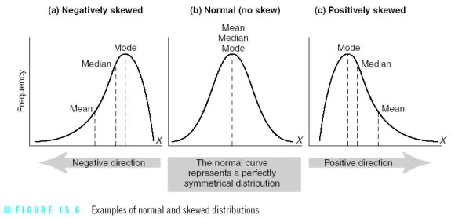

# Bivariate Descriptive Analysis

**Bivariate data** are obtained when we observe two variables (X, Y), numerical or categorical, in a sample of n individuals (x1, y1),(x2, y2), . . . ,(xn, yn).

- Besides analyzing each variable separately, we want to study whether there is any relationship between them, and, if so, analyze that relationship

**Bivariate Analysis** (Conditional Univariate Analysis) is analysis of how one variable is distributed when another variable is held constant

## Frequency Tables

Frequency tables can also be used with two variables. These are called **two-way tables** and show joint frequencies of the variables. When at least one of the variables is qualitative, it is called a **contingency table**.

### Joint Absolute Frequency Tables

Joint absolute frequency for classes ci of X and c′j of Y : nij

[figure not shown]

```r
ConTtable<-table(datavalue,data.df$gender)        #Joint absolute frequencies
ConTtable
```

```
datavalue female male
        1     10    2
        2     17    9
        3     38   26
        4     68   29
        5     53   34
        6     15    9
```

### Joint Relative Frequency Tables

A **joint relative frequency table** shows the proportion of the total data set that falls into a specific category for two variables at the same time. It is created by dividing the joint frequency (the number of occurrences for two paired variables) by the grand total of all data points in the table.

[figure not shown]

Relative frequencies allow us to compare the results of two studies with different sample sizes.

```r
RConTtable<-prop.table(ConTtable)*100 #Joint relative frequencies
RConTtable
```

```
datavalue     female       male
        1  3.2258065  0.6451613
        2  5.4838710  2.9032258
        3 12.2580645  8.3870968
        4 21.9354839  9.3548387
        5 17.0967742 10.9677419
        6  4.8387097  2.9032258
```

#### Marginal Frequencies

**Marginal Frequencies** are the total number of observations within a specific row or column of a two-way frequency table, representing the sum of the joint frequencies for that category, regardless of the other variable.

- Marginal absolute frequency for class ci of X: ni = ni1 + · · · + nim
- Marginal absolute frequency for class c′j of Y : nj = n1j + · · · + nkj

```r
colSums(RConTtable) #Marginal frequencies for gender
```

```
  female     male
64.83871 35.16129
```

```r
rowSums(RConTtable) #Marginal frequencies for Value
```

```
        1         2         3         4         5         6
 3.870968  8.387097 20.645161 31.290323 28.064516  7.741935
```

### Conditional Frequency Tables

**Conditional Frequency** is a statistical measure that describes the proportion of a subgroup within a dataset that meets a specific criterion, calculated by dividing the frequency of that outcome by the total frequency of the subgroup.

Y | X = ci or X | Y = c′j

Some questions that can be answered with conditional frequencies:

- What percentage of sampled individuals who attained a post-secondary education level are unemployed?
- What percentage of sampled individuals who have attained secondary OR post-secondary education level are unemployed?

Example:

What percentage of individuals who have obtained a post-secondary education level are unemployed?

variable X = education level

variable Y = employment status

[output not shown]

Total relative frequency is always equal to one. To get percentages, multiple by 100. The answer would be 1.93%.

Sometimes multiple rows or columns from a two-way table meet a condition - in this case, we sum these rows or columns to get the absolute frequencies for our conditional frequency table. Example:

What percentage of sampled individuals who have obtained a secondary education level **or higher** are unemployed?

Variable X = education level (both secondary and post-secondary)

Variable Y = employment status

[output not shown]

3.3% of sampled individuals who attained a secondary or higher level of education are unemployed.

```r
CConTtableG<-prop.table(ConTtable,margin=2)*100   #Conditional of Value for fixed gender
CConTtableG
```

```
datavalue    female      male
        1  4.975124  1.834862
        2  8.457711  8.256881
        3 18.905473 23.853211
        4 33.830846 26.605505
        5 26.368159 31.192661
        6  7.462687  8.256881
```

## Box Plots for Multiple Variables (One Fixed)

```r
bxp<-ggplot(data.df,mapping=aes(y=value,x=gender))+geom_boxplot(fill="Orange")
dp<-ggplot(data.df,mapping=aes(y=price,x=gender))+geom_boxplot(fill="lightblue")
dp1<-ggplot(data.df,mapping=aes(y=conv,x=gender))+geom_boxplot(fill="Red")


ggarrange(bxp, dp,dp1,
          ncol = 3, nrow = 1)
```

[figure not shown]

## Box Plots for Multiple Variables (One Fixed)

```r
bxp<-ggplot(data.df,mapping=aes(y=value,x=education))+geom_boxplot(fill="Orange")
dp<-ggplot(data.df,mapping=aes(y=price,x=education))+geom_boxplot(fill="lightblue")


ggarrange(bxp, dp,
          ncol = 2, nrow = 1)
```

[figure not shown]

## Conditional Mean and Standard Deviation

```r
data_df_grouped <- group_by(data.df,gender)

sample_size <- data_df_grouped %>%
  dplyr::summarise(n=n()) %>%
  deframe()
sample_size
```

```
female   male
   201    109
```

```r
data_df_summary <-data_df_grouped %>%
  summarise_at(vars(value, price),
               list(avg=mean,stde=sd))
data_df_summary
```

```
# A tibble: 2 × 5
  gender value_avg price_avg value_stde price_stde
  <chr>      <dbl>     <dbl>      <dbl>      <dbl>
1 female      4.49      3.84       1.20      0.940
2 male        4.66      4.03       1.16      0.978
```

## Violin Plot

A **violin plot** is a visualization tool that combines a box plot with a kernel density plot to show the distribution of numerical data across different groups. It is used to compare the central tendency, spread, and density of data distributions, making it useful for spotting differences in data sets, like multimodal distributions or skewness that are not visible in a simple box plot.

```r
ggplot(data.df, aes(x = gender, y = innov, fill=gender)) +
  geom_violin(alpha=0.7)
```

[figure not shown]

## Density Comparison Across Groups

```r
ggplot(data.df, aes(x = innov, fill = gender)) +
  geom_density(alpha=0.4) +
  labs(title="Density comparison by group")
```

[figure not shown]